# Hypothesis tests & probability - homework

# MVP

## Hypothesis testing - practical

You work for an animal conservation organisation and are looking to do some investigating into some of the animals to provide evidence for some projects you are looking to run.

In this homework we’ll use the `msleep` data set provided in the `ggplot` package. It concerns the sleeping patterns of various types of mammal.

```r
library(tidyverse)
data(msleep)
```

**Question 1.**  
Explore the dataset and familiarise yourself with it.

**Ans 1.**

Load libraries

```r
library(tidyverse)
library(infer)
```

View data

```r
data(msleep)

glimpse(msleep)
```

```
Rows: 83
Columns: 11
$ name         <chr> "Cheetah", "Owl monkey", "Mountain beaver", "Greater short-tailed shrew", "Cow", "Three-toed sloth", "Northern f~
$ genus        <chr> "Acinonyx", "Aotus", "Aplodontia", "Blarina", "Bos", "Bradypus", "Callorhinus", "Calomys", "Canis", "Capreolus",~
$ vore         <chr> "carni", "omni", "herbi", "omni", "herbi", "herbi", "carni", NA, "carni", "herbi", "herbi", "herbi", "omni", "he~
$ order        <chr> "Carnivora", "Primates", "Rodentia", "Soricomorpha", "Artiodactyla", "Pilosa", "Carnivora", "Rodentia", "Carnivo~
$ conservation <chr> "lc", NA, "nt", "lc", "domesticated", NA, "vu", NA, "domesticated", "lc", "lc", "domesticated", "lc", "domestica~
$ sleep_total  <dbl> 12.1, 17.0, 14.4, 14.9, 4.0, 14.4, 8.7, 7.0, 10.1, 3.0, 5.3, 9.4, 10.0, 12.5, 10.3, 8.3, 9.1, 17.4, 5.3, 18.0, 3~
$ sleep_rem    <dbl> NA, 1.8, 2.4, 2.3, 0.7, 2.2, 1.4, NA, 2.9, NA, 0.6, 0.8, 0.7, 1.5, 2.2, 2.0, 1.4, 3.1, 0.5, 4.9, NA, 3.9, 0.6, 0~
$ sleep_cycle  <dbl> NA, NA, NA, 0.1333333, 0.6666667, 0.7666667, 0.3833333, NA, 0.3333333, NA, NA, 0.2166667, NA, 0.1166667, NA, NA,~
$ awake        <dbl> 11.90, 7.00, 9.60, 9.10, 20.00, 9.60, 15.30, 17.00, 13.90, 21.00, 18.70, 14.60, 14.00, 11.50, 13.70, 15.70, 14.9~
$ brainwt      <dbl> NA, 0.01550, NA, 0.00029, 0.42300, NA, NA, NA, 0.07000, 0.09820, 0.11500, 0.00550, NA, 0.00640, 0.00100, 0.00660~
$ bodywt       <dbl> 50.000, 0.480, 1.350, 0.019, 600.000, 3.850, 20.490, 0.045, 14.000, 14.800, 33.500, 0.728, 4.750, 0.420, 0.060, ~
```

Check data for NA values

```r
msleep %>%
  summarise(across(.cols = everything(),
                   .fns = ~sum(is.na(.x))))
```

| name | genus | vore | order | conservation | sleep_total | sleep_rem | sleep_cycle | awake | brainwt | bodywt |
| --- | --- | --- | --- | --- | --- | --- | --- | --- | --- | --- |
| 0 | 0 | 7 | 0 | 29 | 0 | 22 | 51 | 0 | 27 | 0 |

```r
NA
```

**Question 2.**  
Jabberwockies sleep for around 7 hours a night, on average. Perform an appropriate statistical test to determine whether the mean `sleep_total` in the sampled population of animal types differs from the typical value for jabberwockies.

**Ans 2.**

View histogram and box plot of `sleep_total`

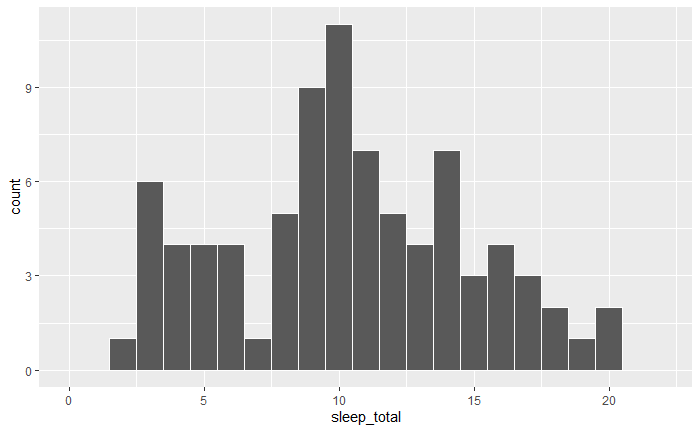

```r
msleep  %>%
  ggplot(aes(x = sleep_total)) +
  geom_histogram(col = "white", binwidth = 1) +
  xlim(0, 22)
```

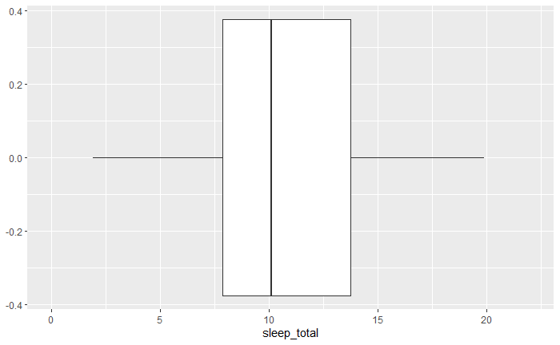

```r
msleep  %>%
  ggplot(aes(x = sleep_total)) +
  geom_boxplot() +
  xlim(0, 22)
```

Mean sleeping hrs of sample (observed statistic)

```r
observed_stat <- msleep %>%
  summarise(mean_sleep = mean(sleep_total))

observed_stat
```

| mean_sleep |
| --- |
| 10.43373 |

The hypothesis test:

$$H_{0}: \mu_{sleep\_total} = 7 \\
H_{a}: \mu_{sleep\_total} \neq 7$$

Calculate the null sampling distribution:

```r
# specify that we want to look at sleep_total variable, 5000 reps, and want to calculate the mean
null_distribution <- msleep %>%
  specify(response = sleep_total) %>%
  hypothesize(null = "point", mu = 7) %>%
  generate(reps = 5000, type = "bootstrap") %>%
  calculate(stat = "mean")
```

Visualise the null distribution and plot observed statistic:

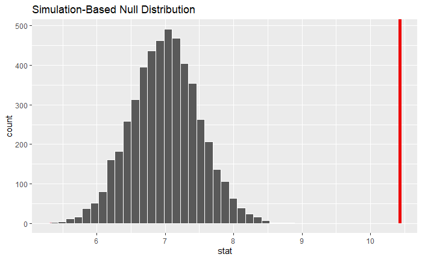

```r
null_distribution %>%
  visualize(bins = 30) +
  shade_p_value(obs_stat = observed_stat$mean_sleep, direction = "both")
```

Calculate p-value

```r
p_value <- null_distribution %>%
  get_p_value(obs_stat = observed_stat$mean_sleep, direction = "both")
p_value
```

| p_value |
| --- |
| 0 |

This outcome (p=0) is no surprise. The mean `sleep_total` in the sampled population of animal types differs significantly from the typical value for jabberwockies (see histogram above).

**Question 3.**  
Perform an appropriate statistical test to determine whether omnivores sleep for significantly longer than herbivores, on average.

**Ans 3.**

Let’s start by setting a significance level $\alpha$ = 0.05, and the hypothesis test (one-tailed):

$$H_{0}: \mu_{omnivore} - \mu_{herbivore} = 0 \\
H_{a}: \mu_{omnivore} - \mu_{herbivore} > 0$$